# MA213 Basic Statistics and Probability - Lab1 Guide

## **Lab 1: Introduction to R**

In this lab session, we will learn basic syntax of R.

## Learning Objectives

- Use R for Data Management and Exploration: Utilize R to load, pre-process, and explore data through visualization and summarization techniques.

#### Install R and RStudio.

You can download and install R from

https://www.r-project.org/

And you can download and install RStudio from

https://posit.co/download/rstudio-desktop/

We assume that you have already installed R and Rstudio (You need to install first R and then install Rstudio because Rstudio is an IDE for R).

## Introduction of R

- R is Programming language and environment statistical computing, data manipulation and graphical display.
- R is free and open source.
- Rstudio is also free and open source IDE (Integrated Development Environment) for R.

## Brief walk through about RStudio interface

[figure not shown]

RStudio overview

window `1` : script window (text editor)

window `2` : console window (this is where you type your R code and run)

window `3` : plots, files, packages, help… window

window `4` : environment window

## Set up `working directory`

- You can go to `Session` → `set working directory` → `choose directory` and then choose your working directory.

  or
- You can go to `Files` tap → ☸︎ →‘copy folder path to Clipboard’

  then paste into `setwd()` function

or

- You can go to `Files` tap → ☸︎ →‘Set As Working Directory’

## How to run code?

1. Directly type your command in the console window.
2. You can run your R chunk by pressing run button `▶` in the R chunk in your R markdown file.
3. You can write your commands on your R script file and highlight the commands and press `run`

```
Run shortcut : `ctrl` + `enter` (windows) or `cmd` + `enter` (mac).
```

## R is basically a big calculator (some mathematics) : basic math operations to matrix operations

> - Basic math operations

> `+`: add

> `-` : substract

> `*` : multiply

> `/` : divide

> `^` or `**`: exponent

## For example

$(\frac{12}{24})^2$

```r
(12/24)^(2)
```

```
## [1] 0.25
```

```r
#or
(12/24)**(2)
```

```
## [1] 0.25
```

## Assign values to a variable

Let’s say if you want to save 10 to variable `A`. You can do the following command.

```r
A <- 10
A <<- 10
10 -> A
10 ->> A
A = 10

# A <- 10
# A = 10
# commonly used ones
```

## And you can check what value the variable `A` has by calling it or using `print()` function

```r
A
```

```
## [1] 10
```

```r
print(A)
```

```
## [1] 10
```

Assigning character type information to a variable

```r
SchoolName <- "Boston University"
SchoolName
```

```
## [1] "Boston University"
```

## Assign values to a vector

You can assign multiple values to a vector.

```r
GPA <- c(3.2, 3.7, 3.9, 2.3, 2.7)
FirstName <- c("Tom", "Sarah", "Nick", "Amy", "John")
GPA
```

```
## [1] 3.2 3.7 3.9 2.3 2.7
```

```r
FirstName
```

```
## [1] "Tom"   "Sarah" "Nick"  "Amy"   "John"
```

There are some useful functions for a vector

- `seq(from=a, to=b, by=c)` : this generates a sequence vector from value a to b by c increment.
- `rep(x, times = n)` : this replicate element `x` for n times.
- `length(x)` : this will give you the length of vector `x`

## Examples

```r
my_vector = seq(1, 10, 2)
my_vector
```

```
## [1] 1 3 5 7 9
```

```r
another_vector = 1:10
another_vector
```

```
##  [1]  1  2  3  4  5  6  7  8  9 10
```

```r
vector3 = rep("BU", 25)
vector3
```

```
##  [1] "BU" "BU" "BU" "BU" "BU" "BU" "BU" "BU" "BU" "BU" "BU" "BU" "BU" "BU" "BU"
## [16] "BU" "BU" "BU" "BU" "BU" "BU" "BU" "BU" "BU" "BU"
```

## Accessing vector elements

Each element in a vector is associated with index number. The index in R starts from 1 as the first item.

For example,

```r
#
SomeNames <- c("Alpha", "Bravo", "Charlie")
```

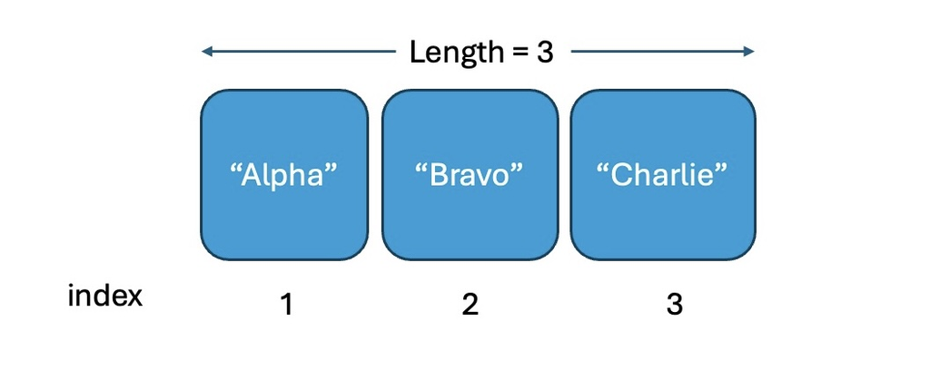

Index of Vector Elements

## For example

You can access the third element of `SomeNames` by `SomeNames[3]` .

You can also access, for example, the second and the third elements by `SomeNames[2:3]` .

```r
#
SomeNames[3]
```

```
## [1] "Charlie"
```

```r
SomeNames[2:3]
```

```
## [1] "Bravo"   "Charlie"
```

## Numeric vector can be subsetted using condition

```r
                         x[condition]
```

the conditional statements (condition) you can use could be

```r
x == 20    # x equals to 20
x < 100
x <= 100
x > 100
x >= 100
x != 100   # x not equal to 100
```

## For example

```r
Numbers <- c(20, 30, 50, 70, 120, 200)
Numbers[Numbers<100]
```

```
## [1] 20 30 50 70
```

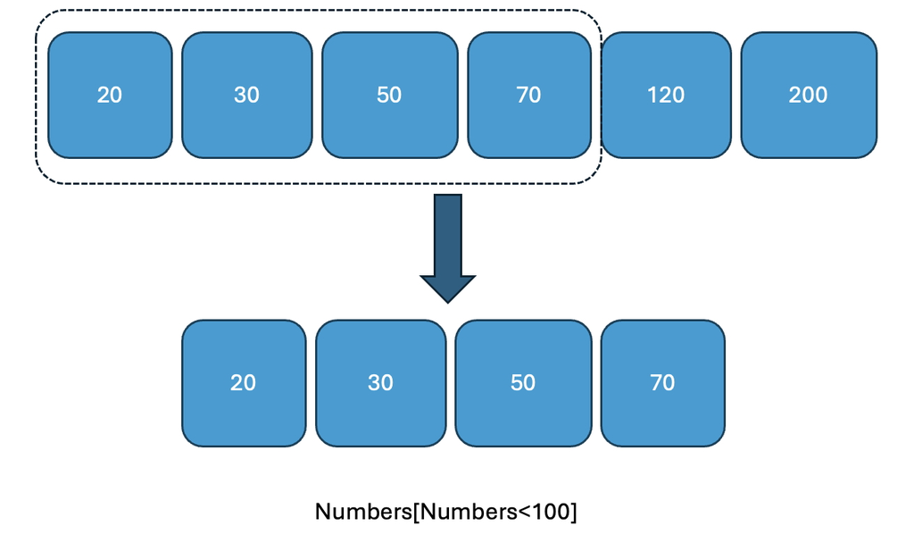

Subsetting vector using condition

## Importing and Subsetting Data

```r
my_data <- read.csv("mtcars.csv")
# to be able to import this file, this file needs to be in your working directory
```

## You can access subset data

- Specific element by `my_data[row, column]`
  - | for example, the element in the third row and the fourth column `my_data[3,4]`
- Specific row by `my_data[row,]`
  - | for example, all the element of the third row `my_data[3,]`

## Also,

- Specific column by `my_data[,column]`
  - | for example, all the element of the fifth column `my_data[,5]`
- Access the column by using `$` sign such as `my_data$column_name`
  - | for example, `hp` column from `my_data` is `my_data$hp`
- Conditional statement works similar as vectors (row wise and column wise)
  - | for example, `my_data[my_data$hp<100,]`

## Multiple conditions can be combined

You can combine multiple logical conditions using & (AND), | (OR), and ! (NOT) operators inside the row index to filter rows. For example

- Rows where `hp` is less than 100 AND `cyl` equals 4:

```r
my_data[(my_data$hp < 100) & (my_data$cyl == 4), ]
```

```
##                 X  mpg cyl  disp hp drat    wt  qsec vs am gear carb
## 3      Datsun 710 22.8   4 108.0 93 3.85 2.320 18.61  1  1    4    1
## 8       Merc 240D 24.4   4 146.7 62 3.69 3.190 20.00  1  0    4    2
## 9        Merc 230 22.8   4 140.8 95 3.92 3.150 22.90  1  0    4    2
## 18       Fiat 128 32.4   4  78.7 66 4.08 2.200 19.47  1  1    4    1
## 19    Honda Civic 30.4   4  75.7 52 4.93 1.615 18.52  1  1    4    2
## 20 Toyota Corolla 33.9   4  71.1 65 4.22 1.835 19.90  1  1    4    1
## 21  Toyota Corona 21.5   4 120.1 97 3.70 2.465 20.01  1  0    3    1
## 26      Fiat X1-9 27.3   4  79.0 66 4.08 1.935 18.90  1  1    4    1
## 27  Porsche 914-2 26.0   4 120.3 91 4.43 2.140 16.70  0  1    5    2
```

- Rows where `hp` is less than 100 OR `cyl` equals 4:

```r
my_data[my_data$hp < 100 | my_data$cyl == 4, ]
```

```
##                 X  mpg cyl  disp  hp drat    wt  qsec vs am gear carb
## 3      Datsun 710 22.8   4 108.0  93 3.85 2.320 18.61  1  1    4    1
## 8       Merc 240D 24.4   4 146.7  62 3.69 3.190 20.00  1  0    4    2
## 9        Merc 230 22.8   4 140.8  95 3.92 3.150 22.90  1  0    4    2
## 18       Fiat 128 32.4   4  78.7  66 4.08 2.200 19.47  1  1    4    1
## 19    Honda Civic 30.4   4  75.7  52 4.93 1.615 18.52  1  1    4    2
## 20 Toyota Corolla 33.9   4  71.1  65 4.22 1.835 19.90  1  1    4    1
## 21  Toyota Corona 21.5   4 120.1  97 3.70 2.465 20.01  1  0    3    1
## 26      Fiat X1-9 27.3   4  79.0  66 4.08 1.935 18.90  1  1    4    1
## 27  Porsche 914-2 26.0   4 120.3  91 4.43 2.140 16.70  0  1    5    2
## 28   Lotus Europa 30.4   4  95.1 113 3.77 1.513 16.90  1  1    5    2
## 32     Volvo 142E 21.4   4 121.0 109 4.11 2.780 18.60  1  1    4    2
```

Rows where `hp` is NOT less than 100:

```r
my_data[! (my_data$hp < 100), ]
```

```
##                      X  mpg cyl  disp  hp drat    wt  qsec vs am gear carb
## 1            Mazda RX4 21.0   6 160.0 110 3.90 2.620 16.46  0  1    4    4
## 2        Mazda RX4 Wag 21.0   6 160.0 110 3.90 2.875 17.02  0  1    4    4
## 4       Hornet 4 Drive 21.4   6 258.0 110 3.08 3.215 19.44  1  0    3    1
## 5    Hornet Sportabout 18.7   8 360.0 175 3.15 3.440 17.02  0  0    3    2
## 6              Valiant 18.1   6 225.0 105 2.76 3.460 20.22  1  0    3    1
## 7           Duster 360 14.3   8 360.0 245 3.21 3.570 15.84  0  0    3    4
## 10            Merc 280 19.2   6 167.6 123 3.92 3.440 18.30  1  0    4    4
## 11           Merc 280C 17.8   6 167.6 123 3.92 3.440 18.90  1  0    4    4
## 12          Merc 450SE 16.4   8 275.8 180 3.07 4.070 17.40  0  0    3    3
## 13          Merc 450SL 17.3   8 275.8 180 3.07 3.730 17.60  0  0    3    3
## 14         Merc 450SLC 15.2   8 275.8 180 3.07 3.780 18.00  0  0    3    3
## 15  Cadillac Fleetwood 10.4   8 472.0 205 2.93 5.250 17.98  0  0    3    4
## 16 Lincoln Continental 10.4   8 460.0 215 3.00 5.424 17.82  0  0    3    4
## 17   Chrysler Imperial 14.7   8 440.0 230 3.23 5.345 17.42  0  0    3    4
## 22    Dodge Challenger 15.5   8 318.0 150 2.76 3.520 16.87  0  0    3    2
## 23         AMC Javelin 15.2   8 304.0 150 3.15 3.435 17.30  0  0    3    2
## 24          Camaro Z28 13.3   8 350.0 245 3.73 3.840 15.41  0  0    3    4
## 25    Pontiac Firebird 19.2   8 400.0 175 3.08 3.845 17.05  0  0    3    2
## 28        Lotus Europa 30.4   4  95.1 113 3.77 1.513 16.90  1  1    5    2
## 29      Ford Pantera L 15.8   8 351.0 264 4.22 3.170 14.50  0  1    5    4
## 30        Ferrari Dino 19.7   6 145.0 175 3.62 2.770 15.50  0  1    5    6
## 31       Maserati Bora 15.0   8 301.0 335 3.54 3.570 14.60  0  1    5    8
## 32          Volvo 142E 21.4   4 121.0 109 4.11 2.780 18.60  1  1    4    2
```

### If an expression or condition is True or False, programming language gives two answers `TRUE` or `FALSE` . It is sometimes can be shown to `1` or `0`.

```r
3==3 # True
```

```
## [1] TRUE
```

```r
10 == 3 # False
```

```
## [1] FALSE
```

```r
my_data$hp < 100 # if the horse power of the car is less than 100 it gives 1, 0 otherwise.
```

```
##  [1] FALSE FALSE  TRUE FALSE FALSE FALSE FALSE  TRUE  TRUE FALSE FALSE FALSE
## [13] FALSE FALSE FALSE FALSE FALSE  TRUE  TRUE  TRUE  TRUE FALSE FALSE FALSE
## [25] FALSE  TRUE  TRUE FALSE FALSE FALSE FALSE FALSE
```

```r
my_data[my_data$hp < 100,] # this is how we are only printing the cars data with horse power < 100.
```

```
##                 X  mpg cyl  disp hp drat    wt  qsec vs am gear carb
## 3      Datsun 710 22.8   4 108.0 93 3.85 2.320 18.61  1  1    4    1
## 8       Merc 240D 24.4   4 146.7 62 3.69 3.190 20.00  1  0    4    2
## 9        Merc 230 22.8   4 140.8 95 3.92 3.150 22.90  1  0    4    2
## 18       Fiat 128 32.4   4  78.7 66 4.08 2.200 19.47  1  1    4    1
## 19    Honda Civic 30.4   4  75.7 52 4.93 1.615 18.52  1  1    4    2
## 20 Toyota Corolla 33.9   4  71.1 65 4.22 1.835 19.90  1  1    4    1
## 21  Toyota Corona 21.5   4 120.1 97 3.70 2.465 20.01  1  0    3    1
## 26      Fiat X1-9 27.3   4  79.0 66 4.08 1.935 18.90  1  1    4    1
## 27  Porsche 914-2 26.0   4 120.3 91 4.43 2.140 16.70  0  1    5    2
```